# Calculating eight potential drivers of the within-population genetic variation

Juliette Archambeau

13 juillet, 2021

In this document, we calculate eight indexs standing for eight potential drivers of the within-population genetic variation:

- **Population admixture** scores $A$ and $D$. $A$ is the raw proportion of admixture for each population (i.e. the proportion of the population genome coming from "foreign" gene pools). $D$ is a the proportion of admixture weighted by the divergence between the source and sink gene pools, i.e. the proportion of belonging to each source gene pool weighted by the divergence between the source and sink gene pool.
- **Climate harshness** indexes $SHM$ (summer heat moisture index) and $invEMT$ (the inverse of the extreme minimum temperature over the period 1901-1950).
- **Environmental heterogeneity** indexes. To calculate these indexes, we selected the raster cells in the 20-km radius around the population locations, performed a PCA based on the cell values of the environmental variables (soil, topographic and climatic variables) and extracted the PC1 and PC2 scores for each cell. With that, we calculated different indexes and selected four for the paper:
  - EH1[20km] the environmental heterogeneity of the **PC1 score** in a **20-km** radius around the population location.
  - EH2[20km] the environmental heterogeneity of the **PC2 score** in a **20-km** radius around the population location.
  - EH1[1.6km] the environmental heterogeneity of the **PC1 score** in a **1.6-km** radius around the population location.
  - EH2[1.6km] the environmental heterogeneity of the **PC2 score** in a **1.6-km** radius around the population location.

We extract the provenance coordinates, transform them in a spatial object and extract the population structure data.

```r
# Provenance coordinates
data <- readRDS(file="data/ClonapinData/PhenoDataNovember2019_AnnualTraits.rds")
df <- unique(data[,c("prov","longitude_prov","latitude_prov")])

# Remove the ROD population because it has no genomic data,
# and the MAD population because it has only one clone (so the genetic variation can't
# be estimated)
df <- df[!(df$prov=="ROD"|df$prov=="MAD"),]
colnames(df) <- c("prov","longitude","latitude")

# Create a spatial object of the provenance coordinates
xyprov <- SpatialPoints(df[,c("longitude","latitude")],
                        proj4string=CRS("+proj=longlat +datum=WGS84"))

# Adding the proportion of belonging to each gene pool (population structure)
gp <- data[!(is.na(data$Q1)),] %>%
  dplyr::select(prov,clon,paste0(rep("Q",6),1:6)) %>%
  distinct() %>%  # keep only one row per clone
  group_by(prov) %>%
  summarise_at(vars(paste0(rep("Q",6),1:6)), mean)

for (i in 1:length(gp$prov)){
  gp[i,"mainGP"] <- names(gp[i,2:7])[which.max(apply(gp[i,2:7],MARGIN=2,max))]
  }
colnames(gp) <- c("prov","gpNA","gpC","gpCS","gpFA","gpIA","gpSES","mainGP")

df <- left_join(df,gp,by="prov")
```

# 1 Population admixture scores

We used estimates from Jaramillo-Correa et al. (2015), that were obtained using the Bayesian approach available in Structure (Pritchard, Stephens, and Donnelly 2000). Jaramillo-Correa et al. (2015) estimated:

- for each clone, the **proportions of ancestry from each of the six known gene pools** in maritime pine. In the `df` dataset, these proportions are averaged by population and correspond to the columns `gpNA`, `gpC`, `gpCS`, `gpFA`, `gpIA` and `gpSES` (see below).
- the **allele frequency divergence of each gene pool from the common ancestral one** (Fk, which should be numerically similar to Fst; Falush et al., 2003):

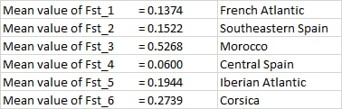

First, we assigned each clone to the gene pool that contributed more than 50% ancestry (corresponding to the column `mainGP` in the `df` dataset, averaged by population).

Then, we calculated the two admixture scores as follows:

- The **population admixture score $A$** corresponds to the proportion of ancestry originating from the "foreign" gene pools.
- To obtain the **admixture score $D$**, we weighted the proportions of ancestry originating from the "foreign" gene pools by the allele frequency divergence between the source and sink gene pools, i.e. the sum of the allele frequency divergence of the source and sink gene pools from the common ancestral one. Thus, the **admixture score $D$** considers both the percentage of ‘foreign’ ancestries and their respective divergence. We developed $D$ considering that some gene pools are more divergent than others and thus may bring higher genetic diversity to an admixed population at the same level of introgression. To check the weights used to calculate $D$, we correlate them with the pairwise $F_{st}$ among gene pools. We also check the correlation between $D$ and $D_{fst}$, i.e. an expected similar index obtained by weighting the proportions of ancestry originating from the "foreign" gene pools by the pairwise $F_{st}$.

$A$ and $D$ values were calculated for each clone and then averaged by population.

## 1.1 Calculating $A$ and $D$

```r
# Estimated divergence between each gene pool and the common ancestral one
# From Jaramillo-Correa et al. (2015)
divNA <- 0.5268   # Northern Africa
divC <- 0.2739    # Corsica
divCS <- 0.0600   # Central Spain
divFA <- 0.1374   # French Atlantic
divIA <- 0.1944   # Iberian Atlantic
divSES <- 0.1522  # South-estern Spain


df <- df %>%
  mutate(mainGP=case_when(mainGP=="Q1"~"gpNA",
                          mainGP=="Q2"~"gpC",
                          mainGP=="Q3"~"gpCS",
                          mainGP=="Q4"~"gpFA",
                          mainGP=="Q5"~"gpIA",
                          mainGP=="Q6"~"gpSES"),

         # Admixture score A:
         A = case_when(mainGP=="gpNA"~1-gpNA,
                       mainGP=="gpC"~1-gpC,
                       mainGP=="gpCS"~1-gpCS,
                       mainGP=="gpFA"~1-gpFA,
                       mainGP=="gpIA"~1-gpIA,
                       mainGP=="gpSES"~1-gpSES),

         # Admixture score D:
         D = case_when(mainGP=="gpNA"~ gpC*(divC+divNA) + gpCS*(divCS+divNA) + gpFA*(divFA+divNA) + gpIA*(divIA+divNA) + gpSES*(divSES+divNA),
                       mainGP=="gpC"~ gpNA*(divNA+divC) + gpCS*(divCS+divC) + gpFA*(divFA+divC) + gpIA*(divIA+divC) + gpSES*(divSES+divC),
                       mainGP=="gpCS"~ gpNA*(divNA+divCS) + gpC*(divC+divCS) + gpFA*(divFA+divCS) + gpIA*(divIA+divCS) + gpSES*(divSES+divCS),
                       mainGP=="gpFA"~ gpNA*(divNA+divFA) + gpC*(divC+divFA) + gpCS*(divCS+divFA) + gpIA*(divIA+divFA) + gpSES*(divSES+divFA),
                       mainGP=="gpIA"~ gpNA*(divNA+divIA) + gpC*(divC+divIA) + gpCS*(divCS+divIA) + gpFA*(divFA+divIA) + gpSES*(divSES+divIA),
                       mainGP=="gpSES"~ gpNA*(divNA+divSES) + gpC*(divC+divSES) + gpCS*(divCS+divSES) + gpFA*(divFA+divSES) + gpIA*(divIA+divSES)))

CorAD <- cor(df$A,df$D)

# Show df
df %>%
  kable(digits=3) %>%
  kable_styling(font_size=11,
                bootstrap_options = c("striped","hover", "condensed"), full_width = F) %>%
  column_spec(1:2, bold = T)
```

| prov | longitude | latitude | gpNA | gpC | gpCS | gpFA | gpIA | gpSES | mainGP | A | D |
| --- | --- | --- | --- | --- | --- | --- | --- | --- | --- | --- | --- |
| CEN | -4.491 | 40.278 | 0.012 | 0.002 | 0.884 | 0.003 | 0.048 | 0.051 | gpCS | 0.116 | 0.031 |
| ARN | -5.116 | 40.195 | 0.010 | 0.002 | 0.955 | 0.008 | 0.010 | 0.014 | gpCS | 0.045 | 0.014 |
| ALT | -6.494 | 43.283 | 0.003 | 0.000 | 0.109 | 0.092 | 0.793 | 0.002 | gpIA | 0.207 | 0.061 |
| SAL | -3.063 | 41.835 | 0.010 | 0.004 | 0.944 | 0.027 | 0.008 | 0.007 | gpCS | 0.056 | 0.016 |
| COM | -3.954 | 36.834 | 0.240 | 0.028 | 0.126 | 0.011 | 0.039 | 0.557 | gpSES | 0.443 | 0.218 |
| CAD | -6.418 | 43.540 | 0.002 | 0.001 | 0.050 | 0.010 | 0.935 | 0.002 | gpIA | 0.065 | 0.018 |
| VAL | -4.311 | 40.516 | 0.012 | 0.003 | 0.940 | 0.007 | 0.013 | 0.025 | gpCS | 0.060 | 0.018 |
| MIM | -1.303 | 44.134 | 0.004 | 0.002 | 0.025 | 0.951 | 0.012 | 0.006 | gpFA | 0.049 | 0.014 |
| LEI | -8.957 | 39.783 | 0.004 | 0.003 | 0.511 | 0.007 | 0.473 | 0.002 | gpCS | 0.489 | 0.125 |
| BAY | -2.877 | 41.523 | 0.003 | 0.004 | 0.967 | 0.013 | 0.009 | 0.004 | gpCS | 0.033 | 0.009 |
| SIE | -6.493 | 43.528 | 0.003 | 0.001 | 0.076 | 0.015 | 0.903 | 0.001 | gpIA | 0.097 | 0.028 |
| LAM | -6.219 | 43.559 | 0.002 | 0.001 | 0.004 | 0.051 | 0.942 | 0.000 | gpIA | 0.058 | 0.020 |
| TAM | -5.017 | 33.600 | 0.932 | 0.000 | 0.027 | 0.000 | 0.039 | 0.001 | gpNA | 0.068 | 0.045 |
| COC | -4.498 | 41.255 | 0.017 | 0.005 | 0.831 | 0.060 | 0.044 | 0.044 | gpCS | 0.169 | 0.044 |
| OLO | -1.831 | 46.566 | 0.003 | 0.001 | 0.007 | 0.979 | 0.006 | 0.003 | gpFA | 0.021 | 0.007 |
| STJ | -2.029 | 46.764 | 0.003 | 0.002 | 0.028 | 0.946 | 0.017 | 0.004 | gpFA | 0.054 | 0.015 |
| CUE | -4.484 | 41.375 | 0.003 | 0.001 | 0.872 | 0.063 | 0.058 | 0.002 | gpCS | 0.128 | 0.030 |
| PET | -1.300 | 44.064 | 0.003 | 0.001 | 0.021 | 0.966 | 0.004 | 0.004 | gpFA | 0.034 | 0.009 |
| ORI | -2.351 | 37.531 | 0.248 | 0.005 | 0.028 | 0.001 | 0.010 | 0.708 | gpSES | 0.292 | 0.180 |
| SEG | -8.450 | 42.817 | 0.003 | 0.001 | 0.149 | 0.013 | 0.831 | 0.003 | gpIA | 0.169 | 0.046 |
| OLB | -0.623 | 40.173 | 0.080 | 0.009 | 0.777 | 0.006 | 0.003 | 0.125 | gpCS | 0.223 | 0.078 |
| QUA | -0.359 | 38.972 | 0.092 | 0.006 | 0.499 | 0.005 | 0.015 | 0.382 | gpCS | 0.501 | 0.142 |
| CAS | -6.983 | 43.501 | 0.001 | 0.000 | 0.005 | 0.001 | 0.992 | 0.001 | gpIA | 0.008 | 0.003 |
| PLE | -2.344 | 47.781 | 0.005 | 0.001 | 0.064 | 0.920 | 0.005 | 0.005 | gpFA | 0.080 | 0.020 |
| BON | -1.661 | 39.986 | 0.164 | 0.010 | 0.640 | 0.003 | 0.002 | 0.181 | gpCS | 0.360 | 0.139 |
| HOU | -1.150 | 45.183 | 0.004 | 0.001 | 0.026 | 0.960 | 0.007 | 0.002 | gpFA | 0.040 | 0.011 |
| VER | -1.091 | 45.552 | 0.003 | 0.002 | 0.018 | 0.972 | 0.004 | 0.001 | gpFA | 0.028 | 0.008 |
| ARM | -6.458 | 43.305 | 0.005 | 0.007 | 0.022 | 0.006 | 0.959 | 0.001 | gpIA | 0.041 | 0.015 |
| CAR | -4.277 | 41.172 | 0.001 | 0.001 | 0.904 | 0.060 | 0.023 | 0.011 | gpCS | 0.096 | 0.021 |
| PIE | 9.038 | 41.973 | 0.007 | 0.969 | 0.023 | 0.000 | 0.001 | 0.001 | gpC | 0.031 | 0.014 |
| PUE | -6.631 | 43.548 | 0.002 | 0.000 | 0.021 | 0.001 | 0.973 | 0.002 | gpIA | 0.027 | 0.008 |
| PIA | 9.465 | 42.021 | 0.004 | 0.974 | 0.010 | 0.001 | 0.008 | 0.003 | gpC | 0.026 | 0.012 |
| SAC | -8.364 | 42.118 | 0.004 | 0.001 | 0.291 | 0.003 | 0.699 | 0.002 | gpIA | 0.301 | 0.079 |

$A$ and $D$ are correlated at 0.91.

## 1.2 Calculating $D_{fst}$

We calculate the pairwise $F_{st}$ matrix among gene pools.

```r
# Script from /home/juliette/Documents/GenomicOffset/GenomicOffsetPinPin/reports/PreparingGenomicData/CalculatingPairwiseFST.Rmd

# File with the genotype names (clone names)
geno_names <- read.delim2("../../GenomicOffset/GenomicOffsetPinPin/data/ClonapinBlups523IndPiMASSJuly2019.txt", row.names=1)

# File with the genotype of each clone for each SNP
geno <- read.csv("../../GenomicOffset/GenomicOffsetPinPin/data/5165snps523genotypesNA.txt", header=FALSE, row.names=1)

# In this file, SNPs have their names, but not the genotypes.
# head(geno[,1:10])

# Removing the first two columns with allele info (A,T, G or C)
geno <- geno[,3:dim(geno)[[2]]]

# Give the genotype name for each column of geno
colnames(geno) <- rownames(geno_names)

# ----

# Preparing genomic data
geno[geno ==1] <- 12
geno[geno ==2] <- 22
geno[geno ==0] <- 11
geno <- t(geno) # SNps in column and genotypes in row

geno <- geno %>%
  as.data.frame() %>%
  dplyr::mutate(prov=substr(row.names(geno), 0, 3)) %>%
   dplyr::filter(!(prov=="MAD")) %>%
  left_join(df[,c("prov","mainGP")],by="prov") %>%
  dplyr::select(prov, mainGP, everything())

# Calculate the pairwise Fst with the hierfstat package
fst <- pairwise.WCfst(geno[,-1],diploid=TRUE)
saveRDS(fst,file="data/GenomicData/Gp_Fstmatrix.rds")
```

We first compare the weights used to calculate $D$ and the pairwise $F_{st}$.

```r
fst <- readRDS(file="data/GenomicData/Gp_Fstmatrix.rds")
fst[lower.tri(fst,diag = FALSE)] <- NA

DFcomp <-  as.data.frame(fst) %>%
  rownames_to_column(var="GP1") %>%
  melt(value.name = "fst",variable.name="GP2") %>%
  drop_na(fst) %>%
  dplyr::mutate(DivGP1 = case_when(GP1=="gpC"~ divC,
                                   GP1=="gpCS"~divCS,
                                   GP1=="gpFA"~divFA,
                                   GP1=="gpIA"~divIA,
                                   GP1=="gpNA"~divNA),
                                 DivGP2 = case_when(GP2=="gpCS"~divCS,
                                   GP2=="gpFA"~divFA,
                                   GP2=="gpIA"~divIA,
                                   GP2=="gpSES"~divSES,
                                   GP2=="gpNA"~divNA),
                                 DivTot=DivGP1+DivGP2)
CorDivTotfst <- cor(DFcomp$DivTot,DFcomp$fst)

DFcomp %>%
  kable(digits=3) %>%
  kable_styling(font_size=11,
                bootstrap_options = c("striped","hover", "condensed"), full_width = F) %>%
  column_spec(1:2, bold = T)
```

| GP1 | GP2 | fst | DivGP1 | DivGP2 | DivTot |
| --- | --- | --- | --- | --- | --- |
| gpC | gpCS | 0.132 | 0.274 | 0.060 | 0.334 |
| gpC | gpFA | 0.185 | 0.274 | 0.137 | 0.411 |
| gpCS | gpFA | 0.071 | 0.060 | 0.137 | 0.197 |
| gpC | gpIA | 0.202 | 0.274 | 0.194 | 0.468 |
| gpCS | gpIA | 0.062 | 0.060 | 0.194 | 0.254 |
| gpFA | gpIA | 0.119 | 0.137 | 0.194 | 0.332 |
| gpC | gpNA | 0.323 | 0.274 | 0.527 | 0.801 |
| gpCS | gpNA | 0.244 | 0.060 | 0.527 | 0.587 |
| gpFA | gpNA | 0.293 | 0.137 | 0.527 | 0.664 |
| gpIA | gpNA | 0.332 | 0.194 | 0.527 | 0.721 |
| gpC | gpSES | 0.175 | 0.274 | 0.152 | 0.426 |
| gpCS | gpSES | 0.083 | 0.060 | 0.152 | 0.212 |
| gpFA | gpSES | 0.150 | 0.137 | 0.152 | 0.290 |
| gpIA | gpSES | 0.163 | 0.194 | 0.152 | 0.347 |
| gpNA | gpSES | 0.157 | 0.527 | 0.152 | 0.679 |

Weights used to calculate $D$ and the pairwise $F_{st}$ are correlated at 0.9.

```r
DFfst <- readRDS(file="data/GenomicData/Gp_Fstmatrix.rds") %>%
  as.data.frame() %>%
  rownames_to_column(var="GP1") %>%
  melt(value.name = "fst",variable.name="GP2") %>%
  drop_na(fst)

df <- df %>% mutate(Dfst = case_when(mainGP=="gpNA"~ gpC*DFfst[DFfst$GP1=="gpC"&DFfst$GP2=="gpNA","fst"] +
                                       gpCS*DFfst[DFfst$GP1=="gpCS"&DFfst$GP2=="gpNA","fst"] +
                                       gpFA*DFfst[DFfst$GP1=="gpFA"&DFfst$GP2=="gpNA","fst"] +
                                       gpIA*DFfst[DFfst$GP1=="gpIA"&DFfst$GP2=="gpNA","fst"] +
                                       gpSES*DFfst[DFfst$GP1=="gpSES"&DFfst$GP2=="gpNA","fst"],
                       mainGP=="gpC"~ gpNA*DFfst[DFfst$GP1=="gpNA"&DFfst$GP2=="gpC","fst"]+
                                       gpCS*DFfst[DFfst$GP1=="gpCS"&DFfst$GP2=="gpC","fst"] +
                                       gpFA*DFfst[DFfst$GP1=="gpFA"&DFfst$GP2=="gpC","fst"] +
                                       gpIA*DFfst[DFfst$GP1=="gpIA"&DFfst$GP2=="gpC","fst"] +
                                       gpSES*DFfst[DFfst$GP1=="gpSES"&DFfst$GP2=="gpC","fst"],
                       mainGP=="gpCS"~ gpNA*DFfst[DFfst$GP1=="gpNA"&DFfst$GP2=="gpCS","fst"] +
                                       gpC*DFfst[DFfst$GP1=="gpC"&DFfst$GP2=="gpCS","fst"] +
                                       gpFA*DFfst[DFfst$GP1=="gpFA"&DFfst$GP2=="gpCS","fst"] +
                                       gpIA*DFfst[DFfst$GP1=="gpIA"&DFfst$GP2=="gpCS","fst"] +
                                       gpSES*DFfst[DFfst$GP1=="gpSES"&DFfst$GP2=="gpCS","fst"],
                       mainGP=="gpFA"~ gpNA*DFfst[DFfst$GP1=="gpNA"&DFfst$GP2=="gpFA","fst"] +
                                       gpC*DFfst[DFfst$GP1=="gpC"&DFfst$GP2=="gpFA","fst"] +
                                       gpCS*DFfst[DFfst$GP1=="gpCS"&DFfst$GP2=="gpFA","fst"] +
                                       gpIA*DFfst[DFfst$GP1=="gpIA"&DFfst$GP2=="gpFA","fst"] +
                                       gpSES*DFfst[DFfst$GP1=="gpSES"&DFfst$GP2=="gpFA","fst"],
                       mainGP=="gpIA"~ gpNA*DFfst[DFfst$GP1=="gpNA"&DFfst$GP2=="gpIA","fst"] +
                                       gpC*DFfst[DFfst$GP1=="gpC"&DFfst$GP2=="gpIA","fst"] +
                                       gpCS*DFfst[DFfst$GP1=="gpCS"&DFfst$GP2=="gpIA","fst"] +
                                       gpFA*DFfst[DFfst$GP1=="gpFA"&DFfst$GP2=="gpIA","fst"] +
                                       gpSES*DFfst[DFfst$GP1=="gpSES"&DFfst$GP2=="gpIA","fst"],
                       mainGP=="gpSES"~ gpNA*DFfst[DFfst$GP1=="gpNA"&DFfst$GP2=="gpSES","fst"] +
                                       gpC*DFfst[DFfst$GP1=="gpC"&DFfst$GP2=="gpSES","fst"] +
                                       gpCS*DFfst[DFfst$GP1=="gpCS"&DFfst$GP2=="gpSES","fst"] +
                                       gpFA*DFfst[DFfst$GP1=="gpFA"&DFfst$GP2=="gpSES","fst"]+
                                       gpIA*DFfst[DFfst$GP1=="gpIA"&DFfst$GP2=="gpSES","fst"]))

CorDDfst <- cor(df$D,df$Dfst)
CorADfst <- cor(df$A,df$Dfst)

# Show df
df %>%
  kable(digits=3) %>%
  kable_styling(font_size=11,
                bootstrap_options = c("striped","hover", "condensed"), full_width = F) %>%
  column_spec(1, bold = T)
```

| prov | longitude | latitude | gpNA | gpC | gpCS | gpFA | gpIA | gpSES | mainGP | A | D | Dfst |
| --- | --- | --- | --- | --- | --- | --- | --- | --- | --- | --- | --- | --- |
| CEN | -4.491 | 40.278 | 0.012 | 0.002 | 0.884 | 0.003 | 0.048 | 0.051 | gpCS | 0.116 | 0.031 | 0.011 |
| ARN | -5.116 | 40.195 | 0.010 | 0.002 | 0.955 | 0.008 | 0.010 | 0.014 | gpCS | 0.045 | 0.014 | 0.005 |
| ALT | -6.494 | 43.283 | 0.003 | 0.000 | 0.109 | 0.092 | 0.793 | 0.002 | gpIA | 0.207 | 0.061 | 0.019 |
| SAL | -3.063 | 41.835 | 0.010 | 0.004 | 0.944 | 0.027 | 0.008 | 0.007 | gpCS | 0.056 | 0.016 | 0.006 |
| COM | -3.954 | 36.834 | 0.240 | 0.028 | 0.126 | 0.011 | 0.039 | 0.557 | gpSES | 0.443 | 0.218 | 0.061 |
| CAD | -6.418 | 43.540 | 0.002 | 0.001 | 0.050 | 0.010 | 0.935 | 0.002 | gpIA | 0.065 | 0.018 | 0.005 |
| VAL | -4.311 | 40.516 | 0.012 | 0.003 | 0.940 | 0.007 | 0.013 | 0.025 | gpCS | 0.060 | 0.018 | 0.007 |
| MIM | -1.303 | 44.134 | 0.004 | 0.002 | 0.025 | 0.951 | 0.012 | 0.006 | gpFA | 0.049 | 0.014 | 0.006 |
| LEI | -8.957 | 39.783 | 0.004 | 0.003 | 0.511 | 0.007 | 0.473 | 0.002 | gpCS | 0.489 | 0.125 | 0.031 |
| BAY | -2.877 | 41.523 | 0.003 | 0.004 | 0.967 | 0.013 | 0.009 | 0.004 | gpCS | 0.033 | 0.009 | 0.003 |
| SIE | -6.493 | 43.528 | 0.003 | 0.001 | 0.076 | 0.015 | 0.903 | 0.001 | gpIA | 0.097 | 0.028 | 0.008 |
| LAM | -6.219 | 43.559 | 0.002 | 0.001 | 0.004 | 0.051 | 0.942 | 0.000 | gpIA | 0.058 | 0.020 | 0.007 |
| TAM | -5.017 | 33.600 | 0.932 | 0.000 | 0.027 | 0.000 | 0.039 | 0.001 | gpNA | 0.068 | 0.045 | 0.020 |
| COC | -4.498 | 41.255 | 0.017 | 0.005 | 0.831 | 0.060 | 0.044 | 0.044 | gpCS | 0.169 | 0.044 | 0.015 |
| OLO | -1.831 | 46.566 | 0.003 | 0.001 | 0.007 | 0.979 | 0.006 | 0.003 | gpFA | 0.021 | 0.007 | 0.003 |
| STJ | -2.029 | 46.764 | 0.003 | 0.002 | 0.028 | 0.946 | 0.017 | 0.004 | gpFA | 0.054 | 0.015 | 0.006 |
| CUE | -4.484 | 41.375 | 0.003 | 0.001 | 0.872 | 0.063 | 0.058 | 0.002 | gpCS | 0.128 | 0.030 | 0.009 |
| PET | -1.300 | 44.064 | 0.003 | 0.001 | 0.021 | 0.966 | 0.004 | 0.004 | gpFA | 0.034 | 0.009 | 0.004 |
| ORI | -2.351 | 37.531 | 0.248 | 0.005 | 0.028 | 0.001 | 0.010 | 0.708 | gpSES | 0.292 | 0.180 | 0.044 |
| SEG | -8.450 | 42.817 | 0.003 | 0.001 | 0.149 | 0.013 | 0.831 | 0.003 | gpIA | 0.169 | 0.046 | 0.012 |
| OLB | -0.623 | 40.173 | 0.080 | 0.009 | 0.777 | 0.006 | 0.003 | 0.125 | gpCS | 0.223 | 0.078 | 0.032 |
| QUA | -0.359 | 38.972 | 0.092 | 0.006 | 0.499 | 0.005 | 0.015 | 0.382 | gpCS | 0.501 | 0.142 | 0.056 |
| CAS | -6.983 | 43.501 | 0.001 | 0.000 | 0.005 | 0.001 | 0.992 | 0.001 | gpIA | 0.008 | 0.003 | 0.001 |
| PLE | -2.344 | 47.781 | 0.005 | 0.001 | 0.064 | 0.920 | 0.005 | 0.005 | gpFA | 0.080 | 0.020 | 0.008 |
| BON | -1.661 | 39.986 | 0.164 | 0.010 | 0.640 | 0.003 | 0.002 | 0.181 | gpCS | 0.360 | 0.139 | 0.057 |
| HOU | -1.150 | 45.183 | 0.004 | 0.001 | 0.026 | 0.960 | 0.007 | 0.002 | gpFA | 0.040 | 0.011 | 0.004 |
| VER | -1.091 | 45.552 | 0.003 | 0.002 | 0.018 | 0.972 | 0.004 | 0.001 | gpFA | 0.028 | 0.008 | 0.003 |
| ARM | -6.458 | 43.305 | 0.005 | 0.007 | 0.022 | 0.006 | 0.959 | 0.001 | gpIA | 0.041 | 0.015 | 0.005 |
| CAR | -4.277 | 41.172 | 0.001 | 0.001 | 0.904 | 0.060 | 0.023 | 0.011 | gpCS | 0.096 | 0.021 | 0.007 |
| PIE | 9.038 | 41.973 | 0.007 | 0.969 | 0.023 | 0.000 | 0.001 | 0.001 | gpC | 0.031 | 0.014 | 0.005 |
| PUE | -6.631 | 43.548 | 0.002 | 0.000 | 0.021 | 0.001 | 0.973 | 0.002 | gpIA | 0.027 | 0.008 | 0.003 |
| PIA | 9.465 | 42.021 | 0.004 | 0.974 | 0.010 | 0.001 | 0.008 | 0.003 | gpC | 0.026 | 0.012 | 0.005 |
| SAC | -8.364 | 42.118 | 0.004 | 0.001 | 0.291 | 0.003 | 0.699 | 0.002 | gpIA | 0.301 | 0.079 | 0.020 |

$A$ and $D_{fst}$ are correlated at 0.91 and $D$ and $D_{fst}$ at 0.96.

# 2 Environmental heterogeneity

## 2.1 Visualization buffer areas + maritime pine distribution

For visualization, we create different potential buffer zones around the location of the populations, respectively with a radius of 5km, 10km, 20km, 50km, 75km and 100km.

```r
buff1 <- buffer(xyprov,width=1000,dissolve=F) # 1km
buff5 <- buffer(xyprov,width=5000,dissolve=F) # 5km
buff10 <- buffer(xyprov,width=10000,dissolve=F) # 10km
buff20 <- buffer(xyprov,width=20000,dissolve=F) # 20km
buff50 <- buffer(xyprov,width=50000,dissolve=F) # 50km
buff75 <- buffer(xyprov,width=75000,dissolve=F) # 75km
buff100 <- buffer(xyprov,width=100000,dissolve=F) # 100km
```

We will project the buffer zones with the **maritime pine distribution**, which is based on the EUFORGEN distribution (http://www.euforgen.org/) and 10-km radius areas around the National Forest Inventory plots with maritime pines (only for Europe). The problem with using this distribution for further analyses is that it is not precise, including non-forested areas and not including the TAM population (Moroccan population). That's why we will not use it in further analyses, and we will use raster of forested areas instead.

```r
# Maritime pine distribution from EUFORGEN and the National Forest Inventories
distri <- shapefile("data/PinPinDistri/PinpinDistriEUforgen_NFIplotsBuffer10km.shp")
```

In the article and the rest of the document, we will use the **buffer areas of 20-km radius**.

# 3 Creating a mask of the forested areas

```r
# Load a raster of one variable that will be used to set the resolution and extent of the mask
# Here precipitation in January with resolution 1000m
prc01 <- raster("data/Climate/Raw/FromMarta_B4ESTClimate/1901-1950_CRU/prc01.tif")
```

### 3.0.1 In Europe

The forested areas are the "Forest Type 2015" of Copernicus. **100 m resolution**. https://land.copernicus.eu/pan-european/high-resolution-layers/forests/forest-type-1/status-maps/2015?tab=metadata

The CRS is **EPSG:3035 (ETRS89, LAEA)** (+proj=laea +lat_0=52 +lon_0=10 +x_0=4321000 +y_0=3210000 +ellps=GRS80 +towgs84=0,0,0,0,0,0,0 +units=m +no_defs).

We keep all the forested areas, so broadleaved forests (1), coniferous forests (2) and mixed forests (3).

Legend:

- **0** all non-tree and non-forest areas
- **1** broadleaved forest
- **2** coniferous forest
- **3** mixed forest (only for aggregated 100m layer)

```r
# Merge the different tiles of Copernicus (100 m resolution)
rast1 <- raster("data/ForestedAreas/RawData/Europe/FTY_2015_100m_eu_03035_d02_E20N20/FTY_2015_100m_eu_03035_d02_E20N20.tif")
rast2 <- raster("data/ForestedAreas/RawData/Europe/FTY_2015_100m_eu_03035_d02_E30N10/FTY_2015_100m_eu_03035_d02_E30N10.tif")
rast3 <- raster("data/ForestedAreas/RawData/Europe/FTY_2015_100m_eu_03035_d02_E30N20/FTY_2015_100m_eu_03035_d02_E30N20.tif")
rast4 <- raster("data/ForestedAreas/RawData/Europe/FTY_2015_100m_eu_03035_d02_E40N20/FTY_2015_100m_eu_03035_d02_E40N20.tif")

# Change the CRS of the buffer areas of 20-km radius in CRS ETRS89-LAEA Europe
buffer <- spTransform(buff20,crs(rast1))

# Keep only raster values within the 20-km radius around each population location
rast1 <- mask(rast1,buffer,updatevalue=NA)
rast2 <- mask(rast2,buffer,updatevalue=NA)
rast3 <- mask(rast3,buffer,updatevalue=NA)
rast4 <- mask(rast4,buffer,updatevalue=NA)


# We keep cells with forested areas, so either broadleaved forests (1), conifer forests (2) or mixed forests (3).
# For that, we attribute 1 to cells with forested areas and 0 to others.

rast1[!(rast1==2|rast1==3|rast1==1)] <- NA
rast2[!(rast2==2|rast2==3|rast2==1)] <- NA
rast3[!(rast3==2|rast3==3|rast3==1)] <- NA
rast4[!(rast4==2|rast4==3|rast4==1)] <- NA

rast1[rast1==2|rast1==3|rast1==1] <- 1
rast2[rast2==2|rast2==3|rast2==1] <- 1
rast3[rast3==2|rast3==3|rast3==1] <- 1
rast4[rast4==2|rast4==3|rast4==1] <- 1

# Save the rasters:
writeRaster(rast1,"data/ForestedAreas/ForestedAreasMasks/EuropeForestAreasRast1.tif",overwrite=T)
writeRaster(rast2,"data/ForestedAreas/ForestedAreasMasks/EuropeForestAreasRast2.tif",overwrite=T)
writeRaster(rast3,"data/ForestedAreas/ForestedAreasMasks/EuropeForestAreasRast3.tif",overwrite=T)
writeRaster(rast4,"data/ForestedAreas/ForestedAreasMasks/EuropeForestAreasRast4.tif",overwrite=T)
```

We use saga version 2.3.1 to combine the tiles together because I did not manage to run the functions `merge` and `mosaic` of the raster package.

```bash
cd ~/Documents/H2Pinpin/H2Pinpin/data/ForestedAreas/ForestedAreasMasks/

# Change the file format so that it can be used by SAGA
saga_cmd io_gdal 0 -GRIDS sagafiles/EuropeForestAreasRast1.sgrd -FILES EuropeForestAreasRast1.tif
saga_cmd io_gdal 0 -GRIDS sagafiles/EuropeForestAreasRast2.sgrd -FILES EuropeForestAreasRast2.tif
saga_cmd io_gdal 0 -GRIDS sagafiles/EuropeForestAreasRast3.sgrd -FILES EuropeForestAreasRast3.tif
saga_cmd io_gdal 0 -GRIDS sagafiles/EuropeForestAreasRast4.sgrd -FILES EuropeForestAreasRast4.tif

# Merging the files (mosaic)
saga_cmd grid_tools 3 -GRIDS sagafiles/EuropeForestAreasRast1.sgrd\;sagafiles/EuropeForestAreasRast2.sgrd\;sagafiles/EuropeForestAreasRast3.sgrd\;sagafiles/EuropeForestAreasRast4.sgrd\
                      -TYPE 7 \
                      -OVERLAP 1 \
                      -BLEND_DIST 10.000000 \
                      -TARGET_OUT_GRID sagafiles/EuropeForestAreas.sgrd

# from format sgrd (SAGA format) to tif
gdal_translate -of GTiff sagafiles/EuropeForestAreas.sdat EuropeForestAreas.tif
```

```r
# Load the mosaic of forested areas tiles
rast <- raster("data/ForestedAreas/ForestedAreasMasks/EuropeForestAreas.tif")

                    # Create a mask at 1000 m resolution and CRS ETRS89-LAEA Europe
eu.mask <- crop(rast,extent(prc01))
eu.mask <- raster::resample(eu.mask,prc01)
eu.mask <- mask(prc01,eu.mask)
```

### 3.0.2 In Morocco

Data downloaded from here: http://www.fao.org/geonetwork/srv/fr/metadata.show?currTab=simple&id=37195

Legend of the LCCCode:

- **0003 / 0004 = Mosaic cropland vegetation**
- **0004 // 0003 = Mosaic vegetation / cropland**
- 0010 = Artficial surfaces and associated areas
- 0011 = Bare areas
- 11490 // 11494 = Rainfed trees and scrub crops
- 11498 = Rainfed cropland
- 20049 // 20058 = Sparse vegetation
- 20058 = Sparse grassland
- **21446 // 21450-121340 / 21454 = Mosaic forest or shrubland/grassland**
- **21450 = Closed to open shrubland**
- **21454 // 21446 // 21450 = Mosaic grassland/forest or shrubland**
- **21496 // 21497-15048 = Closed to open broadleaved evergreen or semidecidous forest**
- **21496-121340 // 21497-129401 = Closed (>40%) broadleaved evergreen or semidecidous forest**
- **21497-121340 = Closed (>40%) broadleaved decidous forest**
- **21497-15045 = Closed to open (>15%) mixed broadleaved decidous and needleaved evergreen forest**
- **21499-121340 = Closed (>40%) needeleaved evergreen forest**
- **21518 = Closed to open broadleaved decidous shrubland**
- 41638-60686-R2 // 41898-60686-R2 = Closed broadleaved forest or shrubland permanently flooded - brakish water
- 6001 = Consolidated bare areas
- 6004 = Non - consolidated bare areas
- 6020 = Salt hardpans
- 7001 // 8001 = Water bodies

We selected cells with the codes in bold.

```r
# Load the data
mor <- shapefile("data/ForestedAreas/RawData/Morocco/mar_gc_adg.shp")

# Keep only the forested areas:
submor <- mor[mor$LCCCode == "21499-121340" |
              mor$LCCCode == "21497-15045" |
              mor$LCCCode == "21454 // 21446 // 21450" |
              mor$LCCCode == "21497-121340" |
              mor$LCCCode == "21496 // 21497-15048" |
              mor$LCCCode == "21496-121340 // 21497-129401" |
              mor$LCCCode == "21446 // 21450-121340 / 21454" |
              mor$LCCCode == "21450" | # added
              mor$LCCCode == "0003 / 0004" | # added
              mor$LCCCode == "0004 // 0003" | # added
              mor$LCCCode == "21518",] # added

# Change the CRS
submor <- spTransform(submor,crs(rast)) # rast is EuropeForestAreas.tif with CRS ETRS89-LAEA Europe

# Change the CRS of the buffer areas of 20 km radius to the CRS ETRS89-LAEA Europe
buffer <- spTransform(buff20,crs(rast))

# intersection with the 20-km buffer
submor <- gIntersection(submor,buffer, byid=TRUE)
plot(out, col="green", bg="white")
plot(xyprov,add=T)

                    # Create the Moroccan mask at 1000m resolution
mor.mask <- crop(prc01,extent(submor))
mor.mask <- mask(mor.mask,submor,updatevalue=NA)

plot(mor.mask)
plot(xyprov,add=T)
```

### 3.0.3 Merge masks of Europe and Morocco

```r
mask <- merge(eu.mask,mor.mask)
writeRaster(mask,"data/ForestedAreas/ForestedAreasMasks/ForestedAreasMask.tif",overwrite=T)
```

## 3.1 Extracting env. variables in the 20-km radius

```r
mask <- raster("data/ForestedAreas/ForestedAreasMasks/ForestedAreasMask.tif") # the mask based on prec01

# We create a dataframe with the non-NAs values of the mask
val <- getValues(mask)
n.val <- length(val)
tab <- tibble(cell.num=1:n.val,mask.values=val) %>% drop_na(mask.values) %>% dplyr::select(-mask.values)
```

**Annual climatic indices**:

- $EMT$: Extreme minimum temperature over the period considered (1901-1950) (°C)
- $SHM$: Summer heat moisture index (°C/mm)
- $PRCsum$: Mean summer precipitation (mm)
- $SPR$: Mean spring precipitation (mm)
- $MWMT$: Mean Warmest Month Temperature (°C)
- $MCMT$: Mean Coldest Month Temperature (°C)
- $TD$: Temperature difference, Celsius degrees (°C) $MWMT-MCMT$

```r
vars <- c("EMT","MCMT","MWMT","PRCsum","SHM","SPR","TD") # annual indices to extract

for(i in vars){
rast.var <- raster(paste0("data/Climate/Raw/FromMaurizio/Annualndices/",i,".tif"))
#rast.var <- crop(rast.var,extent(mask)) # no need, same extent between the two rasters
#rast.var <- raster::resample(rast.var,mask) # no need, same resolution
rast.var <- mask(rast.var,mask,updatevalue=NA) # apply the mask
rast.values <- getValues(rast.var)
tab.vars <- tibble(cell.num=1:length(rast.values),values=rast.values) %>% drop_na(values)
colnames(tab.vars)[2] <- i
tab <- full_join(tab,tab.vars,by="cell.num")
}

sapply(tab, function(x) sum(is.na(x))) # no NAs
```

**Monthly indices (12 variables)**:

- $MinT_{m}$: Monthly minimum temperature (°C)
- $MaxT_{m}$: Monthly maximum temperature (°C)
- $Prec_{m}$: Monthly total precipitation (mm)
- $CMD_{m}$: Hargreaves climatic moisture deficit (mm)

```r
vars <- list.files(path="data/Climate/Raw/FromMaurizio/MonthlyIndices",pattern=".tif")
vars <- vars[-grep("PET",vars)] # remove monthly PET
vars <- str_sub(vars,1,-5) # extract variable names

for(i in vars){
rast.var <- raster(paste0("data/Climate/Raw/FromMaurizio/MonthlyIndices/",i,".tif"))
#rast.var <- crop(rast.var,extent(mask)) # no need, same extent between the two rasters
#rast.var <- raster::resample(rast.var,mask) # no need, same resolution
rast.var <- mask(rast.var,mask,updatevalue=NA) # apply the mask

rast.values <- getValues(rast.var)
tab.vars <- tibble(cell.num=1:length(rast.values),values=rast.values) %>% drop_na(values)
colnames(tab.vars)[2] <- i
tab <- full_join(tab,tab.vars,by="cell.num")
}

sapply(tab, function(x) sum(is.na(x))) # no NAs
```

**Soil variables**:

- $DepthRoots$: Depth available to roots (cm)
- $Clay$: Clay content in the topsoil (0-30 cm) (%)
- $Sand$: Sand content in the topsoil (0-30 cm) (%)
- $Silt$: Silt content in the topsoil (0-30 cm) (%)

```r
soil.rast <- list(raster("../../Pinpin_Clonapin/data/raw-data/soil/DERIVED_LAYERS/STU_EU_DEPTH_ROOTS_WGS84.tif"),
                  raster("../../Pinpin_Clonapin/data/raw-data/soil/DERIVED_LAYERS/STU_EU_T_CLAY_WGS84.tif"),
                  raster("../../Pinpin_Clonapin/data/raw-data/soil/DERIVED_LAYERS/STU_EU_T_SAND_WGS84.tif"),
                  raster("../../Pinpin_Clonapin/data/raw-data/soil/DERIVED_LAYERS/STU_EU_T_SILT_WGS84.tif"))
names(soil.rast) <- c("DepthRoots","Clay","Sand","Silt")

for(i in names(soil.rast)){
rast.var <- projectRaster(soil.rast[[i]],mask)
rast.var <- crop(rast.var,extent(mask)) # same extent between the two rasters
#rast.var <- raster::resample(rast.var,mask) # no need, same resolution
rast.var <- mask(rast.var,mask,updatevalue=NA) # apply the mask

rast.values <- getValues(rast.var)
tab.vars <- tibble(cell.num=1:length(rast.values),values=rast.values) %>% drop_na(values)
colnames(tab.vars)[2] <- i
tab <- full_join(tab,tab.vars,by="cell.num")
}

sapply(tab, function(x) sum(is.na(x)))
```

> Topographic ruggedness index (TRI)

```r
rast.var <- raster("../../GenomicOffset/GenomicOffsetPinPin/data/Topography/TRI/TifsLAEA/TRI_LAEA.tif") # file reprojected from UTM31N to ETRS89 - LAEA in SAGA
rast.var <- crop(rast.var,extent(mask)) # same extent between the two rasters
rast.var <- raster::resample(rast.var,mask) # different resolution because TRI has a 90-m resolution
rast.var <- mask(rast.var,mask,updatevalue=NA) # apply the mask
rast.values <- getValues(rast.var)
tab.vars <- tibble(cell.num=1:length(rast.values),values=rast.values) %>% drop_na(values)
colnames(tab.vars)[2] <- "TRI"
tab <- full_join(tab,tab.vars,by="cell.num")
```

```r
saveRDS(tab,file="data/DF_EnvHetero.rds")
```

## 3.2 Run the PCA

We **perform a PCA** on the selected cell values = cell in forested areas and in 20-km radius around a population location.

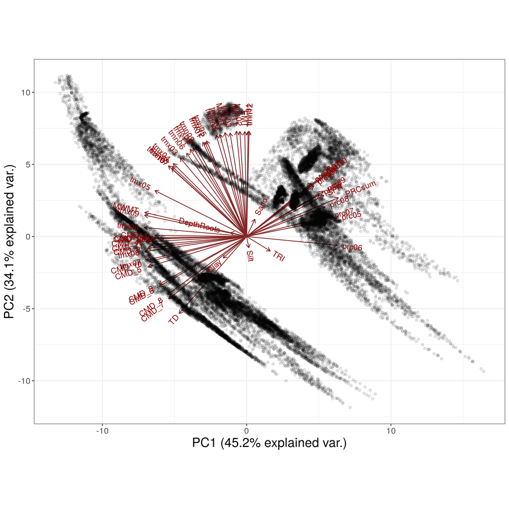

```r
tab <- readRDS(file="data/DF_EnvHetero.rds")

pca <- prcomp(tab[,-1], center = TRUE, scale. = TRUE) # centered and scaled PCA

p <- ggbiplot(pca,obs.scale = 1, var.scale = 1,
         varname.size =4,alpha = 0.1,#labels.size = 10,
         varname.adjust = 1.5) +
  theme_bw() +
  theme(plot.title = element_text(size=18),
        axis.title = element_text(size=18),
        axis.text = element_text(size=12))
p
```

```r
ggsave(p,file="figs/CalculatingDrivers/PCA_EnvHetero.png",width=15,height=12)
```

We **assign the PC1 and PC2 scores** to the cells on the map.

```r
# extract the PC1 and PC2 coordinates of the points (location within 20-km radius around population locations)
tab[,"PC1"] <- pca$x[,"PC1"]
tab[,"PC2"] <- pca$x[,"PC2"]
range(tab$PC1)
```

```
## [1] -13.26144  16.43171
```

```r
range(tab$PC2)
```

```
## [1] -11.84963  11.14772
```

```r
# Assign PC1 and PC2 values to the raster mask
rast.pc2 <- rast.pc1 <- mask
rast.pc1[tab$cell.num] <- pca$x[,"PC1"]
rast.pc2[tab$cell.num] <- pca$x[,"PC2"]
```

## 3.3 Calculate EH and EHW

```r
# xyprov is a spatial object of the provenances coordinates in CRS WGS84
xyprov <- spTransform(xyprov,crs(rast.pc1)) # reproject in ETRS89 - LAEA
df <- df %>% mutate(long.laea = xyprov@coords[,1],lat.laea = xyprov@coords[,2])
```

We first calculate $EH$ for each population as the variance of cell values in the 20-km and 1.6-km radius, such as:

$$EH = \frac{\sum_{ij}(x_{ij} - \bar{x})^2}{n-1}$$

### 3.3.1 20-km radius

```r
# We are going to extract the cell values of the cells in the 20-km radius around the population location

# For PC1
pop.val1 <- extract(rast.pc1, xyprov, buffer=20000,cellnumbers=TRUE) # we obtain a list with 34 elements

# For PC2
pop.val2 <- extract(rast.pc2, xyprov, buffer=20000,cellnumbers=TRUE) # we obtain a list with 34 elements


# We extract for each population:

# Information related to the number of cells with NAs
df[,"Nb.NAs.20km"] <- unlist(lapply(pop.val1, function(x) sum(is.na(x[,"value"])))) # number of NAs
df[,"Nb.val.20km"] <- unlist(lapply(pop.val1, function(x) sum(!is.na(x[,"value"])))) # number of cells with non-NAs values
df[,"Nb.cell.20km"] <- df[,"Nb.NAs.20km"] + df[,"Nb.val.20km"]  # total number of cells

# Environmental heterogeneity index (variance of the values of the cells within the 20-km radius)
df[,"EH.20km.PC1"] <- unlist(lapply(pop.val1, function(x) var(x[,"value"],na.rm=T))) # PC1 score
df[,"EH.20km.PC2"] <- unlist(lapply(pop.val2, function(x) var(x[,"value"],na.rm=T))) # PC2 score
```

Comment: Here, we extracted the cells within a 20 km radius around the population location with the `extract` function, i.e. thus selecting the cells that have their center within the 20 km radius around the population location. In a different way, when the mask was constructed, the cells were selected in a buffer zone around the population location with the `buffer` function, so that cells were included if part of the cell was included in the 20 km radius, which results in a larger number of selected cells.

We calculate $EHW$ for each population as the weighted variance of cell values in the 20-km radius region, such as:

$$EHW = \frac{\sum_{ij}(x_{ij}-\bar{x})^{2}m_{ij}}{\sum_{ij}m_{ij}}$$

where $m_{ij}$ is the weighting at cell $[i,j]$.

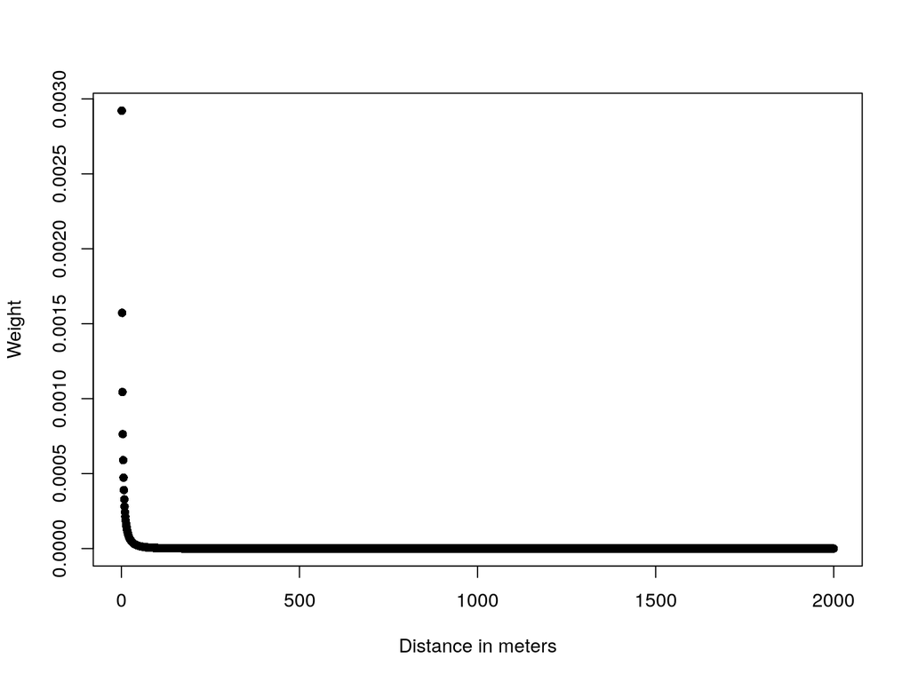

```r
# parameters from De Lucas et al., 2008
c <- 0.2229 # shape parameter
alpha <- 0.0028 # scale parameter

# Visualization of the dispersal kernel with these parameters:
dist = 1:2000
weight=(c/(2*pi*alpha^2*gamma(2/c)))*exp(-((dist)/alpha)^c)
plot(weight,
     xlab="Distance in meters",
     ylab="Weight",
     pch=16)
```

```r
# Adding a threshold of 250 meters representing the radius of the samping area
(c/(2*pi*alpha^2*gamma(2/c)))*exp(-((250)/alpha)^c)
```

```
## [1] 3.659826e-07
```

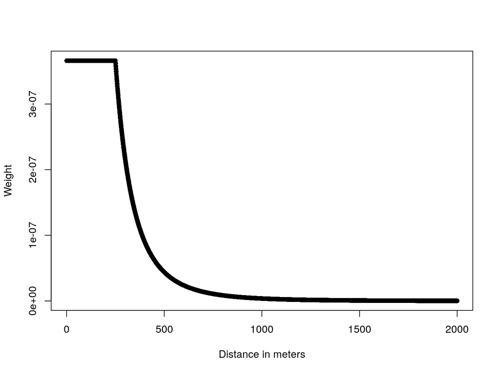

```r
weight <- 1:2000
weight[weight<250]= 3.659826e-07
weight[weight>=250]=(c/(2*pi*alpha^2*gamma(2/c)))*exp(-((weight[weight])/alpha)^c)
plot(weight,
     xlab="Distance in meters",
     ylab="Weight",
     pch=16)
```

[figure not shown]

```r
calcWeights <- function(x,pop.nb,rast){
  coords <-  xyFromCell(rast,x[,1])
  coord.x = coords[,1]
  coord.y = coords[,2]
  dist=pointDistance(xyprov@coords[pop.nb,],coords,lonlat = F)
  weight <- dist
  weight[weight<250] <- 3.659826e-07
  for(i in which(weight>=250)) weight[i] <- (c/(2*pi*alpha^2*gamma(2/c)))*exp(-((weight[i])/alpha)^c)
  x <- cbind(x,coord.x,coord.y,dist,weight)
  x <- as.data.frame(x)
  x <- x[!is.na(x$value),]
  return(x)
}

# plot(weight~dist,
#      xlab="Distance in meters",
#      ylab="Weight",
#      pch=16)

#
# calcWeights <- function(x,pop.nb,rast){
#   coords <-  xyFromCell(rast,x[,1])
#   coord.x = coords[,1]
#   coord.y = coords[,2]
#   dist=pointDistance(xyprov@coords[pop.nb,],coords,lonlat = F)
#   weight=(c/(2*pi*alpha^2*gamma(2/c)))*exp(-((dist+250)/alpha)^c) # if we take 200m, PIA is weird for isntance
#
#   x <- cbind(x,coord.x,coord.y,dist,weight)
#   x <- as.data.frame(x)
#   x <- x[!is.na(x$value),]
#   return(x)
# }

pop.val1 <-mapply(calcWeights, pop.val1,pop.nb=1:33,MoreArgs=list(rast=rast.pc1), SIMPLIFY=F)
pop.val2 <-mapply(calcWeights, pop.val2,pop.nb=1:33,MoreArgs=list(rast=rast.pc2), SIMPLIFY=F)
# For EH (already done before):
#df[,"EH"] <- unlist(lapply(pop.val, function(x) var(x$value)))
# df[,"EH"] <- unlist(lapply(pop.val, function(x) sum((x$value-mean(x$value))^2)/(length(x$cell)-1)))

# Calculation EHW
df[,"EHW.20km.PC1"] <- unlist(lapply(pop.val1, function(x) sum(((x$value-mean(x$value))^2)*x$weight)/sum(x$weight)))
df[,"EHW.20km.PC2"] <- unlist(lapply(pop.val2, function(x) sum(((x$value-mean(x$value))^2)*x$weight)/sum(x$weight)))

df[,"minDist"] <- unlist(lapply(pop.val1, function(x) min(x$dist)))
df[,"meanDist"] <- unlist(lapply(pop.val1, function(x) mean(x$dist,na.rm=T)))
df[,"Dist1000"] <- unlist(lapply(pop.val1, function(x) length(x$cell[x$dist<1000])))
```

### 3.3.2 1.6-km radius

```r
# We are going to extract the cell values of the cells in the 1.6-km radius around the population location

# For PC1
pop.val1 <- extract(rast.pc1, xyprov, buffer=1600,cellnumbers=TRUE) # we obtain a list with 34 elements

# For PC2
pop.val2 <- extract(rast.pc2, xyprov, buffer=1600,cellnumbers=TRUE) # we obtain a list with 34 elements


# We extract for each population:

# Information related to the number of cells with NAs
df[,"Nb.NAs.1km"] <- unlist(lapply(pop.val1, function(x) sum(is.na(x[,"value"])))) # number of NAs
df[,"Nb.val.1km"] <- unlist(lapply(pop.val1, function(x) sum(!is.na(x[,"value"])))) # number of cells with non-NAs values
df[,"Nb.cell.1km"] <- df[,"Nb.NAs.1km"] + df[,"Nb.val.1km"]  # total number of cells

# Environmental heterogeneity index (variance of the values of the cells within the 1.6-km radius)
df[,"EH.1km.PC1"] <- unlist(lapply(pop.val1, function(x) var(x[,"value"],na.rm=T))) # PC1 score
df[,"EH.1km.PC2"] <- unlist(lapply(pop.val2, function(x) var(x[,"value"],na.rm=T))) # PC2 score

df %>%
  dplyr::select(contains("1km")) %>%
  kable(digits=3) %>%
  kable_styling(font_size=11,
                bootstrap_options = c("striped","hover", "condensed"), full_width = F) %>%
  column_spec(1, bold = T)
```

| Nb.NAs.1km | Nb.val.1km | Nb.cell.1km | EH.1km.PC1 | EH.1km.PC2 |
| --- | --- | --- | --- | --- |
| 0 | 8 | 8 | 0.374 | 0.241 |
| 0 | 8 | 8 | 0.542 | 0.387 |
| 0 | 8 | 8 | 0.120 | 0.200 |
| 0 | 8 | 8 | 0.066 | 0.042 |
| 0 | 9 | 9 | 0.859 | 1.763 |
| 0 | 8 | 8 | 0.213 | 0.381 |
| 0 | 9 | 9 | 0.835 | 0.597 |
| 0 | 9 | 9 | 0.005 | 0.011 |
| 0 | 8 | 8 | 0.016 | 0.007 |
| 0 | 9 | 9 | 0.064 | 0.033 |
| 0 | 8 | 8 | 0.464 | 0.774 |
| 0 | 8 | 8 | 0.034 | 0.073 |
| 0 | 8 | 8 | 0.078 | 0.058 |
| 0 | 8 | 8 | 0.001 | 0.000 |
| 2 | 7 | 9 | 0.009 | 0.005 |
| 1 | 7 | 8 | 0.006 | 0.012 |
| 0 | 8 | 8 | 0.001 | 0.002 |
| 0 | 8 | 8 | 0.002 | 0.012 |
| 0 | 8 | 8 | 0.300 | 0.272 |
| 0 | 8 | 8 | 0.104 | 0.092 |
| 0 | 8 | 8 | 0.583 | 0.408 |
| 0 | 8 | 8 | 0.311 | 0.358 |
| 0 | 9 | 9 | 0.241 | 0.287 |
| 0 | 9 | 9 | 0.063 | 0.031 |
| 0 | 8 | 8 | 0.447 | 0.260 |
| 0 | 8 | 8 | 0.006 | 0.012 |
| 2 | 5 | 7 | 0.002 | 0.000 |
| 0 | 8 | 8 | 0.147 | 0.151 |
| 0 | 8 | 8 | 0.002 | 0.012 |
| 0 | 7 | 7 | 0.535 | 0.312 |
| 0 | 8 | 8 | 0.080 | 0.141 |
| 3 | 6 | 9 | 0.009 | 0.011 |
| 0 | 9 | 9 | 1.435 | 0.404 |

```r
# For PC1
pop.val1 <- extract(rast.pc1, xyprov, buffer=3000,cellnumbers=TRUE) # we obtain a list with 34 elements

# For PC2
pop.val2 <- extract(rast.pc2, xyprov, buffer=3000,cellnumbers=TRUE) # we obtain a list with 34 elements

Keep9cells <- function(x,pop.nb,rast){
  coords <-  xyFromCell(rast,x[,1])
  coord.x = coords[,1]
  coord.y = coords[,2]
  dist=pointDistance(xyprov@coords[pop.nb,],coords,lonlat = F)
  weight <- dist
  weight[weight<250] <- 3.659826e-07
  for(i in which(weight>=250)) weight[i] <- (c/(2*pi*alpha^2*gamma(2/c)))*exp(-((weight[i])/alpha)^c)
  x <- cbind(x,coord.x,coord.y,dist)
  x <- as.data.frame(x)
  x <- x[!is.na(x$value),]
  x <- arrange(x,by=dist) %>% slice(1:9)
  return(x)
}

pop.val1 <-mapply(Keep9cells, pop.val1,pop.nb=1:33,MoreArgs=list(rast=rast.pc1), SIMPLIFY=F)
pop.val2 <-mapply(Keep9cells, pop.val2,pop.nb=1:33,MoreArgs=list(rast=rast.pc2), SIMPLIFY=F)

# We extract for each population:

# Information related to the number of cells with NAs
df[,"Nb.NAs.9cells"] <- unlist(lapply(pop.val1, function(x) sum(is.na(x[,"value"])))) # number of NAs
df[,"Nb.val.9cells"] <- unlist(lapply(pop.val1, function(x) sum(!is.na(x[,"value"])))) # number of cells with non-NAs values
df[,"Nb.cell.9cells"] <- df[,"Nb.NAs.1km"] + df[,"Nb.val.1km"]  # total number of cells

# Environmental heterogeneity index (variance of the values of the cells within the 1.6-km radius)
df[,"EH.9cells.PC1"] <- unlist(lapply(pop.val1, function(x) var(x[,"value"],na.rm=T))) # PC1 score
df[,"EH.9cells.PC2"] <- unlist(lapply(pop.val2, function(x) var(x[,"value"],na.rm=T))) # PC2 score

df %>%
  dplyr::select(contains("9cells")) %>%
  kable(digits=3) %>%
  kable_styling(font_size=11,
                bootstrap_options = c("striped","hover", "condensed"), full_width = F) %>%
  column_spec(1, bold = T)
```

| Nb.NAs.9cells | Nb.val.9cells | Nb.cell.9cells | EH.9cells.PC1 | EH.9cells.PC2 |
| --- | --- | --- | --- | --- |
| 0 | 9 | 8 | 0.343 | 0.224 |
| 0 | 9 | 8 | 0.539 | 0.373 |
| 0 | 9 | 8 | 0.105 | 0.175 |
| 0 | 9 | 8 | 0.058 | 0.037 |
| 0 | 9 | 9 | 0.859 | 1.763 |
| 0 | 9 | 8 | 0.197 | 0.345 |
| 0 | 9 | 9 | 0.835 | 0.597 |
| 0 | 9 | 9 | 0.005 | 0.011 |
| 0 | 9 | 8 | 0.014 | 0.007 |
| 0 | 9 | 9 | 0.064 | 0.033 |
| 0 | 9 | 8 | 0.436 | 0.719 |
| 0 | 9 | 8 | 0.043 | 0.086 |
| 0 | 9 | 8 | 0.069 | 0.054 |
| 0 | 9 | 8 | 0.001 | 0.000 |
| 0 | 9 | 9 | 0.012 | 0.005 |
| 0 | 9 | 8 | 0.006 | 0.012 |
| 0 | 9 | 8 | 0.001 | 0.011 |
| 0 | 9 | 8 | 0.002 | 0.013 |
| 0 | 9 | 8 | 0.263 | 0.239 |
| 0 | 9 | 8 | 0.091 | 0.088 |
| 0 | 9 | 8 | 0.549 | 0.379 |
| 0 | 9 | 8 | 0.294 | 0.329 |
| 0 | 9 | 9 | 0.241 | 0.287 |
| 0 | 9 | 9 | 0.063 | 0.031 |
| 0 | 9 | 8 | 0.392 | 0.228 |
| 0 | 9 | 8 | 0.006 | 0.011 |
| 0 | 9 | 7 | 0.003 | 0.002 |
| 0 | 9 | 8 | 0.139 | 0.138 |
| 0 | 9 | 8 | 0.001 | 0.011 |
| 0 | 9 | 7 | 0.675 | 0.382 |
| 0 | 9 | 8 | 0.077 | 0.133 |
| 0 | 9 | 9 | 0.006 | 0.009 |
| 0 | 9 | 9 | 1.435 | 0.404 |

## 3.4 Visualization

## 3.5 Tables (to check variable plausibility)

Correlations among the environmental heterogeneity indexes:

|  | EH.20km.PC1 | EH.20km.PC2 | EHW.20km.PC1 | EHW.20km.PC2 | EH.1km.PC1 | EH.1km.PC2 | EH.9cells.PC1 | EH.9cells.PC2 |
| --- | --- | --- | --- | --- | --- | --- | --- | --- |
| EH.20km.PC1 | 1.000 | 0.778 | 0.279 | 0.137 | 0.561 | 0.333 | 0.600 | 0.356 |
| EH.20km.PC2 | 0.778 | 1.000 | 0.178 | 0.216 | 0.698 | 0.799 | 0.717 | 0.814 |
| EHW.20km.PC1 | 0.279 | 0.178 | 1.000 | 0.877 | 0.010 | -0.036 | -0.006 | -0.046 |
| EHW.20km.PC2 | 0.137 | 0.216 | 0.877 | 1.000 | -0.004 | 0.113 | -0.024 | 0.099 |
| EH.1km.PC1 | 0.561 | 0.698 | 0.010 | -0.004 | 1.000 | 0.686 | 0.996 | 0.689 |
| EH.1km.PC2 | 0.333 | 0.799 | -0.036 | 0.113 | 0.686 | 1.000 | 0.677 | 0.998 |
| EH.9cells.PC1 | 0.600 | 0.717 | -0.006 | -0.024 | 0.996 | 0.677 | 1.000 | 0.685 |
| EH.9cells.PC2 | 0.356 | 0.814 | -0.046 | 0.099 | 0.689 | 0.998 | 0.685 | 1.000 |

At 20-km radius, weak correlation between $EH$ and $EHW$ and the number of no-NA and NA cells:

|  | EH.20km.PC1 | EH.20km.PC2 | EHW.20km.PC1 | EHW.20km.PC2 |
| --- | --- | --- | --- | --- |
| Nb.NAs.20km | -0.329 | -0.258 | -0.067 | 0.073 |
| Nb.val.20km | 0.326 | 0.256 | 0.066 | -0.073 |
| Nb.cell.20km | -0.135 | -0.044 | -0.052 | -0.009 |

|  | EH.1km.PC1 | EH.1km.PC2 |
| --- | --- | --- |
| Nb.NAs.1km | -0.253 | -0.225 |
| Nb.val.1km | 0.358 | 0.327 |
| Nb.cell.1km | 0.228 | 0.215 |

$EH$ at 20-km radius has plausible outputs, while $EHW$ has highly implausible values. See table below the provenance sorted by $EH$ values:

| prov | EH.20km.PC1 | EH.20km.PC2 | EHW.20km.PC1 | EHW.20km.PC2 | EH.1km.PC1 | EH.1km.PC2 | EH.9cells.PC1 | EH.9cells.PC2 |
| --- | --- | --- | --- | --- | --- | --- | --- | --- |
| OLO | 0.0164592 | 0.0777221 | 0.0317397 | 0.2733301 | 0.0094036 | 0.0051262 | 0.0124146 | 0.0054464 |
| HOU | 0.0199138 | 0.0460692 | 0.0575290 | 0.0296516 | 0.0056728 | 0.0120469 | 0.0055989 | 0.0112477 |
| VER | 0.0561962 | 0.0977318 | 0.0382893 | 0.0653611 | 0.0016021 | 0.0004732 | 0.0031340 | 0.0017005 |
| STJ | 0.0724334 | 0.0850043 | 0.1723654 | 0.2262236 | 0.0063682 | 0.0120204 | 0.0064358 | 0.0124672 |
| COC | 0.1023016 | 0.0836111 | 0.0403213 | 0.0192419 | 0.0012808 | 0.0004666 | 0.0011223 | 0.0004108 |
| PET | 0.1132217 | 0.1942967 | 0.0376352 | 0.2054232 | 0.0024650 | 0.0124776 | 0.0022581 | 0.0134366 |
| MIM | 0.1250154 | 0.1430788 | 0.0913257 | 0.2646539 | 0.0048957 | 0.0111053 | 0.0048957 | 0.0111053 |
| CAR | 0.2887455 | 0.0465328 | 0.0126181 | 0.0141989 | 0.0016033 | 0.0116461 | 0.0014398 | 0.0112454 |
| PLE | 0.3107704 | 0.1106614 | 0.0263038 | 0.0182243 | 0.0629047 | 0.0311361 | 0.0629047 | 0.0311361 |
| CUE | 0.4152351 | 0.2634282 | 0.4170237 | 0.0268819 | 0.0013332 | 0.0018250 | 0.0011801 | 0.0114863 |
| LEI | 0.4538560 | 0.2561911 | 0.3405906 | 0.1444059 | 0.0156472 | 0.0068048 | 0.0140602 | 0.0066829 |
| BAY | 0.6007530 | 0.3459568 | 0.5287138 | 0.3859016 | 0.0637982 | 0.0325186 | 0.0637982 | 0.0325186 |
| SEG | 0.9034542 | 1.3105301 | 0.0677415 | 0.0369804 | 0.1039489 | 0.0923702 | 0.0909560 | 0.0875323 |
| LAM | 1.3488393 | 2.8529413 | 1.0252085 | 3.5587077 | 0.0338634 | 0.0730391 | 0.0432421 | 0.0859804 |
| SAL | 1.8213656 | 0.8226303 | 0.3200903 | 0.1758596 | 0.0655126 | 0.0418700 | 0.0578386 | 0.0367636 |
| QUA | 1.8484792 | 2.3982469 | 3.3417721 | 3.8445054 | 0.3108199 | 0.3575822 | 0.2943501 | 0.3289829 |
| PUE | 1.9342907 | 3.3209288 | 1.8429107 | 4.1831515 | 0.0802020 | 0.1410220 | 0.0767704 | 0.1330363 |
| CAD | 1.9428268 | 3.9931115 | 1.3624726 | 3.3910649 | 0.2129489 | 0.3807609 | 0.1967605 | 0.3454852 |
| SIE | 2.2115856 | 4.3160372 | 0.2992390 | 1.2499280 | 0.4638710 | 0.7738594 | 0.4355487 | 0.7194657 |
| BON | 2.2808226 | 1.2513821 | 1.0268501 | 0.6279184 | 0.4466757 | 0.2597429 | 0.3916035 | 0.2277211 |
| ARM | 2.8348172 | 4.2521537 | 1.0388269 | 0.8987438 | 0.1467888 | 0.1510096 | 0.1388638 | 0.1382230 |
| ALT | 3.1157857 | 4.1075309 | 2.6243228 | 2.6275168 | 0.1202799 | 0.2000988 | 0.1052720 | 0.1754711 |
| ORI | 3.3994551 | 4.1103031 | 1.5029619 | 1.7714128 | 0.3001282 | 0.2722580 | 0.2631283 | 0.2388773 |
| CAS | 3.5633689 | 4.8389016 | 1.6972816 | 2.3318921 | 0.2409040 | 0.2871943 | 0.2409040 | 0.2871943 |
| TAM | 3.7733529 | 2.9544629 | 3.8312651 | 2.5875755 | 0.0779903 | 0.0581450 | 0.0693665 | 0.0537996 |
| COM | 6.7168541 | 18.0852393 | 0.3749921 | 1.8162808 | 0.8590390 | 1.7627341 | 0.8590390 | 1.7627341 |
| OLB | 8.2221548 | 6.4686497 | 0.5408123 | 0.3481675 | 0.5826322 | 0.4084071 | 0.5492035 | 0.3793049 |
| SAC | 8.5797279 | 7.2216946 | 1.0098261 | 0.3992617 | 1.4347528 | 0.4037317 | 1.4347528 | 0.4037317 |
| CEN | 8.9757398 | 5.2851221 | 11.2774070 | 7.8438688 | 0.3742971 | 0.2408937 | 0.3428790 | 0.2240336 |
| VAL | 10.7818411 | 6.1634688 | 0.4349211 | 0.3852892 | 0.8354679 | 0.5968357 | 0.8354679 | 0.5968357 |
| PIA | 11.0349900 | 5.8603367 | 9.4426607 | 5.6108793 | 0.0092793 | 0.0111288 | 0.0060671 | 0.0090379 |
| ARN | 21.9499021 | 12.9951842 | 1.2670169 | 0.4598626 | 0.5421156 | 0.3869346 | 0.5393576 | 0.3726968 |
| PIE | 23.6211453 | 11.5244241 | 0.4545641 | 0.1140265 | 0.5346164 | 0.3123310 | 0.6748777 | 0.3823646 |

Same table but sorted by $EH$ at 1.6-km radius:

| prov | EH.20km.PC1 | EH.20km.PC2 | EHW.20km.PC1 | EHW.20km.PC2 | EH.1km.PC1 | EH.1km.PC2 | EH.9cells.PC1 | EH.9cells.PC2 |
| --- | --- | --- | --- | --- | --- | --- | --- | --- |
| COC | 0.1023016 | 0.0836111 | 0.0403213 | 0.0192419 | 0.0012808 | 0.0004666 | 0.0011223 | 0.0004108 |
| CUE | 0.4152351 | 0.2634282 | 0.4170237 | 0.0268819 | 0.0013332 | 0.0018250 | 0.0011801 | 0.0114863 |
| VER | 0.0561962 | 0.0977318 | 0.0382893 | 0.0653611 | 0.0016021 | 0.0004732 | 0.0031340 | 0.0017005 |
| CAR | 0.2887455 | 0.0465328 | 0.0126181 | 0.0141989 | 0.0016033 | 0.0116461 | 0.0014398 | 0.0112454 |
| PET | 0.1132217 | 0.1942967 | 0.0376352 | 0.2054232 | 0.0024650 | 0.0124776 | 0.0022581 | 0.0134366 |
| MIM | 0.1250154 | 0.1430788 | 0.0913257 | 0.2646539 | 0.0048957 | 0.0111053 | 0.0048957 | 0.0111053 |
| HOU | 0.0199138 | 0.0460692 | 0.0575290 | 0.0296516 | 0.0056728 | 0.0120469 | 0.0055989 | 0.0112477 |
| STJ | 0.0724334 | 0.0850043 | 0.1723654 | 0.2262236 | 0.0063682 | 0.0120204 | 0.0064358 | 0.0124672 |
| PIA | 11.0349900 | 5.8603367 | 9.4426607 | 5.6108793 | 0.0092793 | 0.0111288 | 0.0060671 | 0.0090379 |
| OLO | 0.0164592 | 0.0777221 | 0.0317397 | 0.2733301 | 0.0094036 | 0.0051262 | 0.0124146 | 0.0054464 |
| LEI | 0.4538560 | 0.2561911 | 0.3405906 | 0.1444059 | 0.0156472 | 0.0068048 | 0.0140602 | 0.0066829 |
| LAM | 1.3488393 | 2.8529413 | 1.0252085 | 3.5587077 | 0.0338634 | 0.0730391 | 0.0432421 | 0.0859804 |
| PLE | 0.3107704 | 0.1106614 | 0.0263038 | 0.0182243 | 0.0629047 | 0.0311361 | 0.0629047 | 0.0311361 |
| BAY | 0.6007530 | 0.3459568 | 0.5287138 | 0.3859016 | 0.0637982 | 0.0325186 | 0.0637982 | 0.0325186 |
| SAL | 1.8213656 | 0.8226303 | 0.3200903 | 0.1758596 | 0.0655126 | 0.0418700 | 0.0578386 | 0.0367636 |
| TAM | 3.7733529 | 2.9544629 | 3.8312651 | 2.5875755 | 0.0779903 | 0.0581450 | 0.0693665 | 0.0537996 |
| PUE | 1.9342907 | 3.3209288 | 1.8429107 | 4.1831515 | 0.0802020 | 0.1410220 | 0.0767704 | 0.1330363 |
| SEG | 0.9034542 | 1.3105301 | 0.0677415 | 0.0369804 | 0.1039489 | 0.0923702 | 0.0909560 | 0.0875323 |
| ALT | 3.1157857 | 4.1075309 | 2.6243228 | 2.6275168 | 0.1202799 | 0.2000988 | 0.1052720 | 0.1754711 |
| ARM | 2.8348172 | 4.2521537 | 1.0388269 | 0.8987438 | 0.1467888 | 0.1510096 | 0.1388638 | 0.1382230 |
| CAD | 1.9428268 | 3.9931115 | 1.3624726 | 3.3910649 | 0.2129489 | 0.3807609 | 0.1967605 | 0.3454852 |
| CAS | 3.5633689 | 4.8389016 | 1.6972816 | 2.3318921 | 0.2409040 | 0.2871943 | 0.2409040 | 0.2871943 |
| ORI | 3.3994551 | 4.1103031 | 1.5029619 | 1.7714128 | 0.3001282 | 0.2722580 | 0.2631283 | 0.2388773 |
| QUA | 1.8484792 | 2.3982469 | 3.3417721 | 3.8445054 | 0.3108199 | 0.3575822 | 0.2943501 | 0.3289829 |
| CEN | 8.9757398 | 5.2851221 | 11.2774070 | 7.8438688 | 0.3742971 | 0.2408937 | 0.3428790 | 0.2240336 |
| BON | 2.2808226 | 1.2513821 | 1.0268501 | 0.6279184 | 0.4466757 | 0.2597429 | 0.3916035 | 0.2277211 |
| SIE | 2.2115856 | 4.3160372 | 0.2992390 | 1.2499280 | 0.4638710 | 0.7738594 | 0.4355487 | 0.7194657 |
| PIE | 23.6211453 | 11.5244241 | 0.4545641 | 0.1140265 | 0.5346164 | 0.3123310 | 0.6748777 | 0.3823646 |
| ARN | 21.9499021 | 12.9951842 | 1.2670169 | 0.4598626 | 0.5421156 | 0.3869346 | 0.5393576 | 0.3726968 |
| OLB | 8.2221548 | 6.4686497 | 0.5408123 | 0.3481675 | 0.5826322 | 0.4084071 | 0.5492035 | 0.3793049 |
| VAL | 10.7818411 | 6.1634688 | 0.4349211 | 0.3852892 | 0.8354679 | 0.5968357 | 0.8354679 | 0.5968357 |
| COM | 6.7168541 | 18.0852393 | 0.3749921 | 1.8162808 | 0.8590390 | 1.7627341 | 0.8590390 | 1.7627341 |
| SAC | 8.5797279 | 7.2216946 | 1.0098261 | 0.3992617 | 1.4347528 | 0.4037317 | 1.4347528 | 0.4037317 |

In the following analyses, we are going to use $EH$ at 20-km radius for both PC1 and PC2 scores (**EH1[20km]** and **EH2[20km]**) and $EH$ at 1.6-km radius for both PC1 and PC2 too (**EH1[1.6km]** and **EH2[1.6km]**).

# 4 Climate harshness

## 4.1 Summer heat moisture index

The higher the $SHM$, the drier the weather.

```r
var <- "SHM"
rast.var <- raster(paste0("data/Climate/Raw/FromMaurizio/Annualndices/",var,".tif"))
df[,var] <- extract(rast.var, xyprov) #
df %>%
  dplyr::select(prov,SHM) %>%
  arrange(by=SHM) %>%
  kable() %>%
  kable_styling(font_size=11,bootstrap_options = c("striped","hover", "condensed"), full_width = F) %>%
  column_spec(1, bold = T)
```

| prov | SHM |
| --- | --- |
| PET | 81.15 |
| MIM | 81.40 |
| PLE | 110.25 |
| HOU | 116.07 |
| STJ | 116.67 |
| OLO | 118.24 |
| VER | 120.37 |
| SEG | 124.04 |
| ARM | 131.58 |
| SAC | 132.37 |
| SIE | 136.74 |
| ALT | 137.60 |
| CAD | 141.86 |
| CAS | 143.36 |
| PUE | 147.64 |
| LAM | 149.21 |
| PIE | 190.91 |
| OLB | 200.00 |
| SAL | 218.18 |
| BON | 254.22 |
| LEI | 279.87 |
| BAY | 280.41 |
| QUA | 305.13 |
| PIA | 332.14 |
| CEN | 356.90 |
| CAR | 379.46 |
| VAL | 382.14 |
| CUE | 383.64 |
| COC | 384.55 |
| ORI | 447.00 |
| TAM | 510.71 |
| ARN | 520.45 |
| COM | 762.90 |

The mean summer heat moisture index across populations is 247.79 °C/mm.

## 4.2 Extreme minimum temperature

$EMT$: the extreme minimum temperature over the period considered (1901-1950). For intepretation, we are going to use $invEMT$ ($=-EMT$).

```r
var <- "EMT"
rast.var <- raster(paste0("data/Climate/Raw/FromMaurizio/Annualndices/",var,".tif"))
df[,var] <- extract(rast.var, xyprov) # EMT
df[,paste0("inv",var)] <- extract(rast.var, xyprov) * (-1) # change the sign of EMT to ease interpretation
df %>%
  dplyr::select(prov,invEMT) %>%
  arrange(by=invEMT) %>%
  kable() %>%
  kable_styling(font_size=11,bootstrap_options = c("striped","hover", "condensed"), full_width = F) %>%
  column_spec(1, bold = T)
```

| prov | invEMT |
| --- | --- |
| LEI | 3.4 |
| PIA | 6.8 |
| LAM | 7.8 |
| PUE | 8.0 |
| CAD | 9.3 |
| CAS | 9.3 |
| MIM | 9.6 |
| PET | 9.6 |
| QUA | 9.8 |
| SEG | 9.9 |
| STJ | 10.2 |
| OLO | 10.4 |
| SIE | 10.6 |
| VER | 10.9 |
| HOU | 11.2 |
| PLE | 11.9 |
| COM | 12.1 |
| SAC | 12.8 |
| ALT | 13.9 |
| ARM | 14.7 |
| PIE | 14.9 |
| ARN | 15.2 |
| CAR | 16.7 |
| COC | 16.8 |
| CUE | 16.8 |
| VAL | 17.6 |
| BAY | 18.4 |
| ORI | 18.9 |
| CEN | 19.2 |
| SAL | 20.7 |
| OLB | 20.8 |
| BON | 21.7 |
| TAM | 23.3 |

The mean extreme minimum temperature across populations is -13.43 °C.

# 5 Climatic transfer distances

Site coordinates:

```r
df.site <- unique(data[,c("site","longitude_site","latitude_site")])

# Create a spatial object
xysite <- SpatialPoints(df.site[,c("longitude_site","latitude_site")],
                        proj4string=CRS("+proj=longlat +datum=WGS84"))

# change CRS
xysite <- spTransform(xysite,crs(mask)) # reproject in ETRS89 - LAEA

for(x in c("EMT","SHM")){
  rast <- raster(paste0("data/Climate/Raw/FromMaurizio/Annualndices/",x,".tif"))
  df.site[,paste0(x,"_site")] <- raster::extract(rast,xysite)
}

df.site  %>%
  kable(digits=3) %>%
  kable_styling(font_size=11,
                bootstrap_options = c("striped","hover", "condensed"), full_width = F) %>%
  column_spec(1, bold = T)
```

| site | longitude_site | latitude_site | EMT_site | SHM_site |
| --- | --- | --- | --- | --- |
| asturias | -6.544 | 43.421 | -12.5 | 134.47 |
| bordeaux | -0.784 | 44.745 | -13.3 | 105.91 |
| portugal | -7.483 | 40.110 | -14.3 | 274.31 |

Create the columns with the climatic transfer distances:

```r
df <- df %>%
  dplyr::mutate(CTD_asturias_EMT=(EMT-df.site[df.site$site=="asturias","EMT_site"] %>% pull()) %>% abs(),
                CTD_asturias_SHM=(SHM-df.site[df.site$site=="asturias","SHM_site"] %>% pull()) %>% abs(),
                CTD_bordeaux_EMT=(EMT-df.site[df.site$site=="bordeaux","EMT_site"] %>% pull()) %>% abs(),
                CTD_bordeaux_SHM=(SHM-df.site[df.site$site=="bordeaux","SHM_site"] %>% pull()) %>% abs(),
                CTD_portugal_EMT=(EMT-df.site[df.site$site=="portugal","EMT_site"] %>% pull()) %>% abs(),
                CTD_portugal_SHM=(SHM-df.site[df.site$site=="portugal","SHM_site"] %>% pull()) %>% abs())

df %>%
  dplyr::select(prov,contains("CTD")) %>%
  arrange(by=CTD_asturias_EMT) %>%
  kable(digits=2) %>%
  kable_styling(font_size=11,bootstrap_options = c("striped","hover", "condensed"), full_width = F) %>%
  column_spec(1, bold = T)
```

| prov | CTD_asturias_EMT | CTD_asturias_SHM | CTD_bordeaux_EMT | CTD_bordeaux_SHM | CTD_portugal_EMT | CTD_portugal_SHM |
| --- | --- | --- | --- | --- | --- | --- |
| SAC | 0.3 | 2.10 | 0.5 | 26.46 | 1.5 | 141.94 |
| COM | 0.4 | 628.43 | 1.2 | 656.99 | 2.2 | 488.59 |
| PLE | 0.6 | 24.22 | 1.4 | 4.34 | 2.4 | 164.06 |
| HOU | 1.3 | 18.40 | 2.1 | 10.16 | 3.1 | 158.24 |
| ALT | 1.4 | 3.13 | 0.6 | 31.69 | 0.4 | 136.71 |
| VER | 1.6 | 14.10 | 2.4 | 14.46 | 3.4 | 153.94 |
| SIE | 1.9 | 2.27 | 2.7 | 30.83 | 3.7 | 137.57 |
| OLO | 2.1 | 16.23 | 2.9 | 12.33 | 3.9 | 156.07 |
| ARM | 2.2 | 2.89 | 1.4 | 25.67 | 0.4 | 142.73 |
| STJ | 2.3 | 17.80 | 3.1 | 10.76 | 4.1 | 157.64 |
| PIE | 2.4 | 56.44 | 1.6 | 85.00 | 0.6 | 83.40 |
| SEG | 2.6 | 10.43 | 3.4 | 18.13 | 4.4 | 150.27 |
| ARN | 2.7 | 385.98 | 1.9 | 414.54 | 0.9 | 246.14 |
| QUA | 2.7 | 170.66 | 3.5 | 199.22 | 4.5 | 30.82 |
| MIM | 2.9 | 53.07 | 3.7 | 24.51 | 4.7 | 192.91 |
| PET | 2.9 | 53.32 | 3.7 | 24.76 | 4.7 | 193.16 |
| CAD | 3.2 | 7.39 | 4.0 | 35.95 | 5.0 | 132.45 |
| CAS | 3.2 | 8.89 | 4.0 | 37.45 | 5.0 | 130.95 |
| CAR | 4.2 | 244.99 | 3.4 | 273.55 | 2.4 | 105.15 |
| COC | 4.3 | 250.08 | 3.5 | 278.64 | 2.5 | 110.24 |
| CUE | 4.3 | 249.17 | 3.5 | 277.73 | 2.5 | 109.33 |
| PUE | 4.5 | 13.17 | 5.3 | 41.73 | 6.3 | 126.67 |
| LAM | 4.7 | 14.74 | 5.5 | 43.30 | 6.5 | 125.10 |
| VAL | 5.1 | 247.67 | 4.3 | 276.23 | 3.3 | 107.83 |
| PIA | 5.7 | 197.67 | 6.5 | 226.23 | 7.5 | 57.83 |
| BAY | 5.9 | 145.94 | 5.1 | 174.50 | 4.1 | 6.10 |
| ORI | 6.4 | 312.53 | 5.6 | 341.09 | 4.6 | 172.69 |
| CEN | 6.7 | 222.43 | 5.9 | 250.99 | 4.9 | 82.59 |
| SAL | 8.2 | 83.71 | 7.4 | 112.27 | 6.4 | 56.13 |
| OLB | 8.3 | 65.53 | 7.5 | 94.09 | 6.5 | 74.31 |
| LEI | 9.1 | 145.40 | 9.9 | 173.96 | 10.9 | 5.56 |
| BON | 9.2 | 119.75 | 8.4 | 148.31 | 7.4 | 20.09 |
| TAM | 10.8 | 376.24 | 10.0 | 404.80 | 9.0 | 236.40 |

```r
df %>%
  dplyr::select(contains("EMT"),contains("SHM"),-EMT) %>%
  cor() %>%
  lower.triangle() %>%
  kable(digits=3) %>%
  kable_styling(font_size=11,
                bootstrap_options = c("striped","hover", "condensed"), full_width = F) %>%
  column_spec(1, bold = T)
```

|  | invEMT | CTD_asturias_EMT | CTD_bordeaux_EMT | CTD_portugal_EMT | SHM | CTD_asturias_SHM | CTD_bordeaux_SHM | CTD_portugal_SHM |
| --- | --- | --- | --- | --- | --- | --- | --- | --- |
| invEMT | 1.000 | 0.000 | 0.000 | 0.000 | 0.000 | 0.000 | 0.000 | 0 |
| CTD_asturias_EMT | 0.484 | 1.000 | 0.000 | 0.000 | 0.000 | 0.000 | 0.000 | 0 |
| CTD_bordeaux_EMT | 0.253 | 0.958 | 1.000 | 0.000 | 0.000 | 0.000 | 0.000 | 0 |
| CTD_portugal_EMT | -0.099 | 0.769 | 0.919 | 1.000 | 0.000 | 0.000 | 0.000 | 0 |
| SHM | 0.406 | 0.291 | 0.191 | 0.016 | 1.000 | 0.000 | 0.000 | 0 |
| CTD_asturias_SHM | 0.377 | 0.252 | 0.165 | 0.009 | 0.986 | 1.000 | 0.000 | 0 |
| CTD_bordeaux_SHM | 0.398 | 0.287 | 0.191 | 0.020 | 0.997 | 0.994 | 1.000 | 0 |
| CTD_portugal_SHM | -0.067 | -0.437 | -0.411 | -0.328 | 0.403 | 0.475 | 0.424 | 1 |

# 6 Correlations

Correlations among the potential drivers:

```r
df %>% dplyr::select(A,D,EH.20km.PC1,EH.20km.PC2,
                     EH.1km.PC1,EH.1km.PC2,SHM,invEMT) %>%
  cor() %>%
  lower.triangle() %>%
  kable(digits=3) %>%
  kable_styling(font_size=11,
                bootstrap_options = c("striped","hover", "condensed"), full_width = F) %>%
  column_spec(1, bold = T)
```

|  | A | D | EH.20km.PC1 | EH.20km.PC2 | EH.1km.PC1 | EH.1km.PC2 | SHM | invEMT |
| --- | --- | --- | --- | --- | --- | --- | --- | --- |
| A | 1.000 | 0.000 | 0.000 | 0.000 | 0.000 | 0.000 | 0.000 | 0 |
| D | 0.914 | 1.000 | 0.000 | 0.000 | 0.000 | 0.000 | 0.000 | 0 |
| EH.20km.PC1 | -0.071 | -0.013 | 1.000 | 0.000 | 0.000 | 0.000 | 0.000 | 0 |
| EH.20km.PC2 | 0.197 | 0.349 | 0.778 | 1.000 | 0.000 | 0.000 | 0.000 | 0 |
| EH.1km.PC1 | 0.375 | 0.400 | 0.561 | 0.698 | 1.000 | 0.000 | 0.000 | 0 |
| EH.1km.PC2 | 0.420 | 0.565 | 0.333 | 0.799 | 0.686 | 1.000 | 0.000 | 0 |
| SHM | 0.381 | 0.536 | 0.335 | 0.541 | 0.275 | 0.519 | 1.000 | 0 |
| invEMT | -0.009 | 0.126 | 0.197 | 0.082 | 0.218 | 0.044 | 0.406 | 1 |

Correlations between the potential drivers and the altitude of the populations:

```r
readRDS(file="data/ClonapinData/PhenoDataNovember2019_AnnualTraits.rds") %>%
  dplyr::filter(!(prov=="MAD")) %>%
  dplyr::select(prov,altitude_prov) %>%
  distinct() %>%
  inner_join(df,by="prov") %>%
  dplyr::select(A,D,EH.20km.PC1,EH.20km.PC2,
                EH.1km.PC1,EH.1km.PC2,SHM,invEMT,altitude_prov) %>%
  cor() %>%
  upper.triangle() %>%
  as.data.frame() %>%
  dplyr::select(altitude_prov) %>%
  kable(digits=3) %>%
  kable_styling(font_size=11,
                bootstrap_options = c("striped","hover", "condensed"), full_width = F)
```

|  | altitude_prov |
| --- | --- |
| A | 0.180 |
| D | 0.333 |
| EH.20km.PC1 | 0.268 |
| EH.20km.PC2 | 0.268 |
| EH.1km.PC1 | 0.258 |
| EH.1km.PC2 | 0.226 |
| SHM | 0.659 |
| invEMT | 0.905 |
| altitude_prov | 1.000 |

```r
saveRDS(df,file="data/DF_Drivers.rds")
```

# Bibliography

Jaramillo-Correa, Juan-Pablo, Isabel Rodríguez-Quilón, Delphine Grivet, Camille Lepoittevin, Federico Sebastiani, Myriam Heuertz, Pauline H Garnier-Géré, et al. 2015. “Molecular Proxies for Climate Maladaptation in a Long-Lived Tree (Pinus Pinaster Aiton, Pinaceae).” *Genetics* 199 (3). Oxford University Press: 793–807.

Pritchard, Jonathan K, Matthew Stephens, and Peter Donnelly. 2000. “Inference of Population Structure Using Multilocus Genotype Data.” *Genetics* 155 (2). Oxford University Press: 945–59.